# Visualizing Volatility Using Matplotlib

In this project we are mainly going to use matplotlib to create some graphs out of time-series stock data. We will be analyzing both daily returns and the volatility of FANG (Facebook, Apple, Netflix, Google) portfolio, and then graphing the volatility using matplotlib.

To start with, let's make the necessary imports:

- Pandas (for dataframes and data analysis)
- Matplotlib (for graphing purposes)
- Datetime (convert datetime in a format that can be processed by Pandas)

As with most financial applications using Python, these are the three most important libraries to have at your disposal.

```python
import pandas as pd
import matplotlib.pyplot as plt
import pandas_datareader.data as web
import datetime as dt
%matplotlib inline
```

First, we will specify the range of time we want to pull our data out from.

```python
start_date = dt.datetime(2017,1,1)
end_date = dt.datetime(2018,1,1)
```

Next, we create a list of ticker symbols for our FANG assets, and then create an empty dataframe where we can store stock data we pulled out from pandas.

Note that we will only be needing the "Adjusted Close" prices from each stock to perform our analysis

In this project, we will be pulling out data from the Quandl API, during the time frame specified above. (1 year's worth)

```python
assets = ['FB', 'AAPL', 'NFLX', 'GOOGL']

df = pd.DataFrame()

for stock in assets:
    df[stock] = web.DataReader(stock, data_source = 'quandl', start = start_date, end = end_date)['AdjClose']

# Let's check the data
df.head() # Prints the first 5 rows of the dataframe
```

| Date | FB | AAPL | NFLX | GOOGL |
| --- | --- | --- | --- | --- |
| 2017-12-29 | 176.46 | 169.23 | 191.96 | 1053.40 |
| 2017-12-28 | 177.92 | 171.08 | 192.71 | 1055.95 |
| 2017-12-27 | 177.62 | 170.60 | 186.24 | 1060.20 |
| 2017-12-26 | 175.99 | 170.57 | 187.76 | 1065.85 |
| 2017-12-22 | 177.20 | 175.01 | 189.94 | 1068.86 |

In order to prepare the dataframe for our analysis, we actually need the daily returns of each stock (expressed as a percentage change).

After we get the daily returns, we can use it to also get the daily volatilities of each asset using pandas.

```python
# Get the daily returns (percentage value)
asset_returns_daily = df.pct_change()

# Get the daily volatilities
asset_daily_volatility = asset_returns_daily.std()
```

We can check what each dataframe now looks like by printing the first 5 rows.

```python
asset_returns_daily.head()
```

| Date | FB | AAPL | NFLX | GOOGL |
| --- | --- | --- | --- | --- |
| 2017-12-29 | NaN | NaN | NaN | NaN |
| 2017-12-28 | 0.008274 | 0.010932 | 0.003907 | 0.002421 |
| 2017-12-27 | -0.001686 | -0.002806 | -0.033574 | 0.004025 |
| 2017-12-26 | -0.009177 | -0.000176 | 0.008162 | 0.005329 |
| 2017-12-22 | 0.006875 | 0.026030 | 0.011611 | 0.002824 |

```python
asset_daily_volatility.head()
```

```
FB       0.010746
AAPL     0.011100
NFLX     0.017149
GOOGL    0.009562
dtype: float64
```

Note that the first row in daily returns is NaN. This is because in order to compute daily returns you need at least 2 periods (in this case days) of data, but there is no row above the first row for us to calculate it.

In this case since we are only graphing them using matplotlib it will not be a problem. However in the future please note that for other analysis we will have to remove the first row.

Now we will use matplotlib to plot the daily returns.

```
Text(0,0.5,'Daily Returns')
```

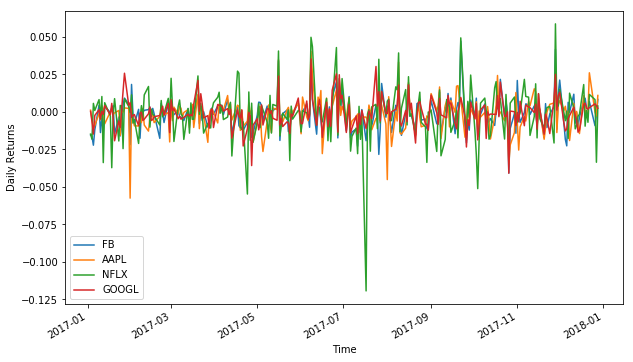

```python
asset_returns_daily.plot(figsize = (10,6))
# Label the x- and y-axis
plt.xlabel('Time')
plt.ylabel('Daily Returns')
```

We can also use a histogram to plot it.

```
Text(0.5,0,'Daily Returns Histogram')
```

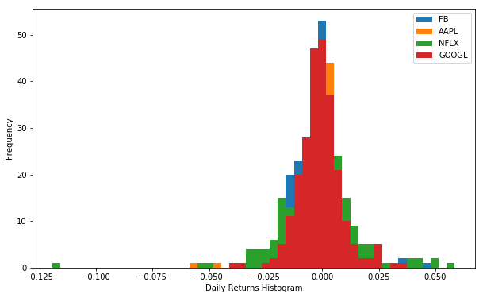

```python
asset_returns_daily.plot.hist(bins = 50, figsize = (10,6))
plt.xlabel('Daily Returns Histogram')
```

©Regio Abundan. May 31st, 2018.